# Recurrent Neural Networks (RNNs) to Predict Hate Speech

- Author: Robert Lartigue

### Imports and a few helper functions

Before I begin, I will import the necessary modules and define a few helper functions I use throughout the course of this lab. I chose to place them up here out of the way to avoid incoherence in the lab itself.

```python
import pandas as pd
import numpy as np

import matplotlib.pyplot as plt
import seaborn as sns

import itertools

import pickle

from sklearn.preprocessing import LabelEncoder
from sklearn.model_selection import train_test_split, StratifiedKFold
from sklearn.metrics import recall_score, f1_score, confusion_matrix, make_scorer
from sklearn.metrics import roc_curve, auc
from scipy import interp
from sklearn.manifold import TSNE


import keras
from keras.preprocessing import sequence
from keras.preprocessing.sequence import pad_sequences
from keras.preprocessing.text import Tokenizer
from keras.layers import Embedding, Dense, LSTM, GRU
from keras.models import Sequential, load_model
from keras.utils import to_categorical
from keras.callbacks import EarlyStopping
from keras.wrappers.scikit_learn import KerasClassifier

import missingno as mn
import pprint
```

```python
def summarize_rnn(rnn, X_test, y_test, title_text = ''):

    classes = ['Hate', 'Neither', 'Offensive']
    cmap = plt.cm.Blues

    yhat = rnn.predict_classes(X_test)
    recall = recall_score(y_test, yhat, average = 'weighted')
    cm = confusion_matrix(y_test, yhat)

    cm = cm.astype('float') / cm.sum(axis=1)[:, np.newaxis]

    plt.imshow(cm, interpolation = 'nearest', cmap = cmap)
    plt.title(f'{title_text} | Recall Score: {recall:.2f}')
    plt.colorbar()
    tick_marks = np.arange(len(classes))
    plt.xticks(tick_marks, classes, rotation=0)
    plt.yticks(tick_marks, classes)

    fmt = '.2f'
    thresh = cm.max() / 2.
    for i, j in itertools.product(range(cm.shape[0]), range(cm.shape[1])):
        plt.text(j, i, format(cm[i, j], fmt),
                 horizontalalignment="center",
                 color="white" if cm[i, j] > thresh else "black")

    plt.tight_layout()
    plt.ylabel('True label')
    plt.xlabel('Predicted label')
    plt.show()

# Code Reference: http://scikit-learn.org/stable/auto_examples/model_selection/plot_confusion_matrix.html
# Code Reference: Eric Larson. https://github.com/eclarson/MachineLearningNotebooks/blob/master/11.%20Convolutional%20Neural%20Networks.ipynb
```

```python
def decode_sequence(sequence):
    sequence_decoded = []
    for _ in sequence:
        if _ == 0:
            pass
        else:
            word_decoded = int_to_word[_]
            sequence_decoded.append(word_decoded)
    return sequence_decoded
```

# 1. Dataset

The dataset used for this assignment contains ~15K tweets, collected from twitter, classified into 3 categories:

1) The tweet is not offensive. (neither)

2) The tweet uses offensive language but not hate speech. (offensive)

3) The tweet contains hate speech. (hate)

This dataset was collected by Thomas Davidson, Dana Warmsley, Michael Macy, and Ingmar Weber, for a paper / research project entitled 'Automated Hate Speech Detection and the Problem of Offensive Language[1].' This dataset was collected using crowd sourcing to collect and classify tweets containing hate speech, offensive language, and plain old tweets.

[1] Thomas Davidson, Dana Warmsley, Michael Macy, and Ingmar Weber. 2017. "Automated Hate Speech Detection and the Problem of Offensive Language." Proceedings of the 11th International Conference on Web and Social Media (ICWSM). The paper is available here https://aaai.org/ocs/index.php/ICWSM/ICWSM17/paper/view/15665

# 2. Business Understanding

Social media runs rampant with hate speech. Racial slurs, derogatory remarks, and targeted verbal abuse, can be found on across all social media platforms whether it be Facebook, Instagram, or Twitter, to name a few.

Across most major social media platforms there is some form of content censorship software backed by a supervisory team tasked with reviewing and removing content deemed inappropriate per the company's policy. A continual problem for these censorship algorithms is to distinguish hate speech from other instances of offensive language. Past lexical detection methods have suffered from poor performance because distinguishing between what is considered hate speech and what is considered offensive language is incredibly difficult for algorithms to accomplish. Such methods typically classify all messages containing certain words as either hate speech or offensive and thus have had difficulty distinguishing the two categories.

The dataset used for this assignment contains ~15K tweets collected from Twitter categorized by humans into 3 categories: tweets containing hate speech (hate), tweets containing offensive language (but is not considered hate speech)(offensive), and tweets that are not considered hate speech or offensive (neither).

The primary classification task of this algorithm is to determine if tweets contain hate speech. To achieve this objective, the algorithm needs to accomplish two other classification tasks. First, The algorithm needs to be able to distinguish between tweets containing hate speech, offensive language, or neither, and second, the algorithm needs to be able to distinguish between tweets containing hate speech and offensive language, which is where the majority of confusions occur.

In examining the classification task of this algorithm, the primary objective is to determine if tweets contain hate speech. In doing so, our primary user, Twitter, could deploy this algorithm on its platform and detect cases of tweets containing hate speech as they occur. The reason for the need to distinguish between hate speech and offensive language is because per company policy tweets containing hate speech may not be tolerated and removed from the platform immediately, while offensive tweets (tweets containing profanity) may be subject to review, however be allowed to be posted, due to peoples second amendment rights. If every tweet containing profanity was removed from the platform, Twitter's users would be limited in their right to freedom of speech and most likely find another place to voice their opinion. BBC news recently reported regarding Twitter "The challenge for the company has been to grapple with offensive content while not being seen to censor views[3]." Thus, in order to rid the platform of hate speech while still allowing individuals to freely express views, Twitter's ability to distinguish between hate speech and offensive content is of paramount importance[3]

The baseline algorithm I need to outperform, is the algorithm developed by Thomas Davidson, Dana Warmsley, Michael Macy, and Ingmar Weber, in their research paper, which was the primary inspiration for this lab. In their best performing algorithm they achieved an overall precision of 0.91, recall of 0.90, and F1 score of 0.90. The confusion matrix for their best performing model is shown in the figure below.

However, since the evaluation metric I found most appropriate for this classification task is recall, a recall score of 0.90 is my primary baseline. Thus, in order beat the competition and consider my algorithm deployable, I need to achieve a recall score of greater than 0.90.

$$ Recall\hspace{1mm}(r) = \frac{True\hspace{1mm} Positives} {True\hspace{1mm} Positives\hspace{1mm} + \hspace{1mm}False\hspace{1mm}Negatives} > 0.90$$

The targeted user for the algorithm developed in this assignment is Twitter, which has an estimated 10,000 tweets per day posted containing hate speech posted on its platform. However, this algorithm could be applied to any social media platform such as Google, Facebook, or Instagram.

[1] http://www.dailymail.co.uk/sciencetech/article-2558890/Just-racist-Twitter-Study-finds-10-000-slurs-DAY-posted-social-network.html [2] https://arxiv.org/pdf/1703.04009.pdf [3] http://www.bbc.com/news/technology-42376546

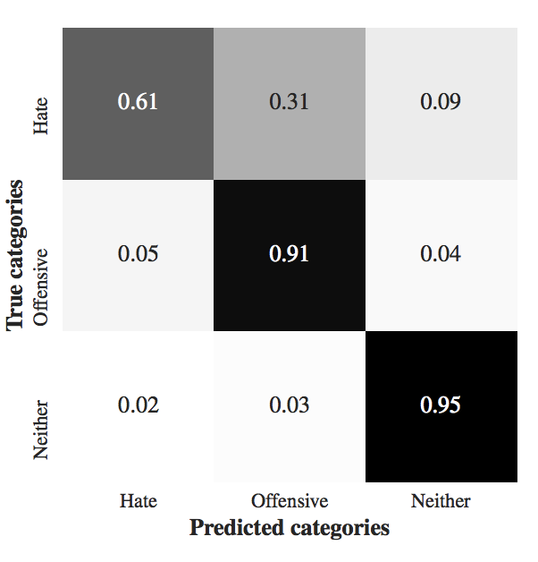

```python
from IPython.display import Image
Image('BaselineConfusion.png')
```

# 3. Data Preparation

The following section contains all data preprocessing steps necessary to prepare the dataset for use in the recurrent neural networks in this assignment.

### 3.1 Load the Dataset

```python
# From Data world cite this
df = pd.read_csv('twitter_hate_speech.csv')
```

```python
df.info()
```

```
<class 'pandas.core.frame.DataFrame'>
RangeIndex: 14509 entries, 0 to 14508
Data columns (total 20 columns):
_unit_id                                           14509 non-null int64
_golden                                            14509 non-null bool
_unit_state                                        14509 non-null object
_trusted_judgments                                 14509 non-null int64
_last_judgment_at                                  14442 non-null object
does_this_tweet_contain_hate_speech                14509 non-null object
does_this_tweet_contain_hate_speech:confidence     14509 non-null float64
_created_at                                        0 non-null float64
orig__golden                                       67 non-null object
orig__last_judgment_at                             0 non-null float64
orig__trusted_judgments                            67 non-null float64
orig__unit_id                                      67 non-null float64
orig__unit_state                                   67 non-null object
_updated_at                                        0 non-null float64
orig_does_this_tweet_contain_hate_speech           67 non-null object
does_this_tweet_contain_hate_speech_gold           67 non-null object
does_this_tweet_contain_hate_speech_gold_reason    0 non-null float64
does_this_tweet_contain_hate_speechconfidence      67 non-null float64
tweet_id                                           14509 non-null float64
tweet_text                                         14509 non-null object
dtypes: bool(1), float64(9), int64(2), object(8)
memory usage: 2.1+ MB
```

### 3.2 Eliminate Unnecessary Columns

As seen in the dataset information above, there are numerous features in this dataset that are irrelevant for the scope of this assignment. I also found many features were ambiguously defined and difficult to interpret. Luckily I am only interested in two columns of this dataset: 'tweet_text' and 'does_this_tweet_contain_hate_speech'.

Also as can be seen above, there are numerous variations of columns indicating whether the tweet contains hate text or not. However as seen in the dataset info above, there is only one official column which contains data for every tweet, thus this was the obvious choice.

The rest of the information in not necessary for this assignment and can be thrown away, as solely the text and target variable are needed for use in RNNs.

```python
# Grab the two columns of interest
df = df[['does_this_tweet_contain_hate_speech', 'tweet_text']].copy()
```

```python
# rename the column headers per class syntax
df = df.rename(columns = {'does_this_tweet_contain_hate_speech': 'target'})
```

```python
df.iloc[50:52] # I used these two instances to sensor the output for public viewing. Some instances are pretty explicit.
```

|  | target | tweet_text |
| --- | --- | --- |
| 50 | The tweet uses offensive language but not hate... | RT @macktology101: "Sunday funday" hoe quotes |
| 51 | The tweet uses offensive language but not hate... | I know these bitches did not leave me, AGAIN. ... |

### 3.3 Examine Data Qualilty

Let's examine the quality of the processed dataset by checking for completeness and duplicate entries, using a missingno matrix and df.duplicated method shown in the code below.

I should note my first pass through this assignment I left out the the step where I check for duplicates in the dataset, making this step below solely superficial, due to the fact I already trained and saved the results of the RNNs in this assignment. However I will include it now to illustrate the point that this should have been done!

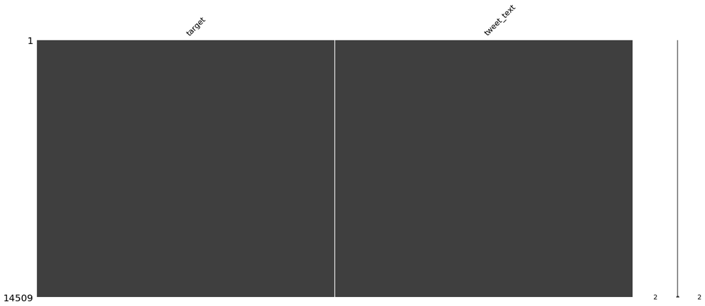

```python
# Let's check for missing entries
mn.matrix(df);
```

As seen in the missingno matrix above the dataset contains no missing entries.

```python
df.duplicated(subset = 'tweet_text').value_counts()
```

```
False    13534
True       975
dtype: int64
```

As seen in the df.duplicated method there are 975 duplicated tweets in this dataset, which should have been removed!!!

### 3.4 Classification Example

This section is solely for the reader of this lab to understand the classification task at hand, by illustrating a few examples of the type of tweets these algorithms are attempting to classify.

Lets take a look at a few examples of tweet text and its target class that I'm hoping to be able to classify using RNNs. Below is an example of tweet text from each target class:

```python
# print('Tweet Text:', df.tweet_text[870])
# print('Target:', df.target[1])
# print('\n')

# I Have ommited the 'The tweet contains hate speech' target class due to public viewing of this notebook.

print('Tweet Text:', df.tweet_text[101])
print('Target:', df.target[101])
print('\n')

print('Tweet Text:', df.tweet_text[9])
print('Target:', df.target[9])
print('\n')
```

```
Tweet Text: @Lawln @Akbar_Knows why would I hashtag my Twitter name if it was really me lol
Target: The tweet is not offensive


Tweet Text: I'm tired of people saying I look like my brother &amp; calling me Deondre' like serious Succ My Ass fag asses
Target: The tweet uses offensive language but not hate speech
```

### 3.5 Preprocessing

###### 3.5.1 Padding the RNN Input Length

As seen in the tweets displayed above, the tweets in this dataset have varying length, as would be expected in practical circumstances. Due two the nature of varying length in tweets, in using RNNs to classify these tweets, I am faced with two options regarding how to handle the text input length to feed to the RNNs:

1) Feed the individual lengths of all the tweets into the RNN or

2) pad or truncate the length of the tweet to a constant value, making all tweets the same sequence length.

If I were to feed the individual lengths of all the tweet into the RNN, the RNN would need to have a varying input size and this would require continual updates to the computation graph under the keras hood making this cumbersome, time consuming, and inefficient.

```python
# Get the length of the longest tweet
print('Max Tweet Length:', df.tweet_text.str.len().max())
print('Min Tweet Length:', df.tweet_text.str.len().min())
print('Mean Tweet Length:', round(df.tweet_text.str.len().mean()))
```

```
Max Tweet Length: 469
Min Tweet Length: 4
Mean Tweet Length: 89.0
```

```python
num_top_words = None
max_tweet_length = round(df.tweet_text.str.len().mean())
```

###### 3.3.2 Tokenize the Text

One cannot simply place words into an RNN and expect them to understand what is going on. We must find a way to speak the computers language and represent these sequences of words (what we humans call sentences) into sequences of something a computer would understand. In order to do this, we use a method called tokenization. Tokenizing is the act of breaking up a sequence of strings into pieces such as word, keywords, phrases, symbols, and other elements called tokens. In the process of tokenization, punctuation and other unnecessary characters are discarded from the strings. Once the sentences, or sequences of words, have been broken into their tokens, the tokenization gives each unique word, keyword, phrase, or symbol, a unique integer representation. Thus, sentences are now be represented by a series of integers which correspond to words, phrases, keywords, and symbols.

In the block of code below, a tokenizer object is created and fit on the tweets in this dataset. To understand what tokenzation actually does, an example of a tokenized tweet is shown below along with its decoding (which is shown after I create the dictionary mapping necessary for decoding).

```python
# Create a tokenizer and fit
tokenizer = Tokenizer(num_words = num_top_words)
tokenizer.fit_on_texts(df.tweet_text)
sequences = tokenizer.texts_to_sequences(df.tweet_text)
```

```python
# This is now how the 101 tweet in the dataset is represented as tokens
sequences[101]
```

```
[5923, 862, 648, 88, 122, 4, 4423, 13, 295, 397, 33, 17, 51, 140, 18, 102]
```

###### 3.3.3 Create dictioinaries to map words to tokens and tokens to words

Below two dictionaries are created. The first (word_to_int) contains the mapping of the word in the tweets to its tokenized integer representation. The second (int_to_word) contains the mapping of the tokenized integer to the word it represents.

```python
word_to_int = tokenizer.word_index
int_to_word = {v: k for k, v in word_to_int.items()}
```

```python
# This is the first tweet in our dataset decoded
decode_sequence(sequences[101])
```

```
['lawln',
 'akbar',
 'knows',
 'why',
 'would',
 'i',
 'hashtag',
 'my',
 'twitter',
 'name',
 'if',
 'it',
 'was',
 'really',
 'me',
 'lol']
```

###### 3.3.4 Pad all sequences to be the same length

```python
X = pad_sequences(sequences, maxlen = max_tweet_length)
```

```python
# View the padded first tweet
X[0]
```

```
array([   0,    0,    0,    0,    0,    0,    0,    0,    0,    0,    0,
          0,    0,    0,    0,    0,    0,    0,    0,    0,    0,    0,
          0,    0,    0,    0,    0,    0,    0,    0,    0,    0,    0,
          0,    0,    0,    0,    0,    0,    0,    0,    0,    0,    0,
          0,    0,    0,    0,    0,    0,    0,    0,    0,    0,    0,
          0,    0,    0,    0,    0,    0,    0,    0,    0,    0,    0,
          0,    0,    0,    0,    0,    0,    0,    0,    0,    0,    0,
          0,    0,    0,    0, 3564, 5874, 9436,   90,  106,    3,    1,
         22], dtype=int32)
```

###### 3.3.5 One Hot Encode the Target Variable

For use in the keras, the target variable must also be transformed into a format the computer can understand. Below I perform two processing steps to the target variable to prepare it for the RNNs,

1) Label encode the text representation of the target variable to obtain an integer representation of each class.

2) One hot encode the label encoded integers for keras

```python
# 1) Label Encode the 3 classes to transform them from text to integers
# 2) One Hot Encode the now integer classes
n_classes = 3
y = LabelEncoder().fit_transform(df.target)
y_ohe = keras.utils.to_categorical(y, num_classes=n_classes)
```

With the label encoding it is important not to lose track of which class is mapped to which integer representation. Below is a dictionary that contains the label encoded class mapping to text representation of the class.

```python
class_dict = {0: 'The tweet contains hate speech',
              1: 'The tweet is not offensive',
              2: 'The tweet uses offensive language but not hate speech'}
```

| Class | Description |
| --- | --- |
| Class 0 | The tweet contains hate speech |
| Class 1 | The tweet is not offensive |
| Class 2 | The tweet uses offensive language but not hate speech |

###### 3.3.6 Initial Train / Test Split for Holdout Technique

Below I chose to perform and INITIAL train / test split on the data to enable the use of a holdout technique. Using this method, the K-Fold cross validation loops below will only use the training data to train and validate the performance of the RNNs. Thus, the test set created here will have never been seen by the RNNs and used to test the performance of the RNNs only after they have been adequately trained.

```python
# Initial Split for hold out technique
X_train, X_test, y_train, y_test = train_test_split(X, y, test_size = 0.2, stratify = y, random_state = 42)
```

```python
# One Hot Encode y_train and y_test
y_train_ohe = to_categorical(y_train, n_classes)
y_test_ohe = to_categorical(y_test, n_classes)
```

### 3.4 Description of the Final Dataset

The processed dataset that will be used for classification in the RNNs in this assignment contains ~15K tweets that have been tokenized (converted from text into numerical sequences) and padded to all be the same length of 89 tokens.

The target class is now a one hot encoded representation of the original target variable representing the 3 target classes, shown in the class dictionary below.

```python
class_dict
```

```
{0: 'The tweet contains hate speech',
 1: 'The tweet is not offensive',
 2: 'The tweet uses offensive language but not hate speech'}
```

# 4. Performance Evaluation Metric

In choosing an appropriate evaluation metric to evaluate algorithm performance, it is crucial to first understand the classification task and business application of this algorithm. As stated in the business case, the classification task of this algorithm is to determine if tweets containing hate speech. To do this, this algorithm must distinguish tweets containing hate speech from tweets containing offensive language (but not considered hate speech) and tweets that are not considered hate speech or offensive.

Let's consider an example to bring to light the evaluation metric that is most appropriate for this classification task. After the last presidential election, the people of America were divided and turned to social media to express political views and beliefs, and take out their frustrations. With this came a vast amount of tweets containing offensive language and hate speech, exchanged between people of opposite political parties. Twitter, now using our algorithm, combats this issue by running our algorithm through a tweet thread where this activity has been occurring. Due to their recent crackdown on hate speech, they want to remove all instances of tweets containing hate speech from the thread. Our algorithm detected numerous tweets containing hate speech and they are removed from the thread. Now, Twitter believes the thread is free of hate speech. But, what if our algorithm predicted that tweets containing hate speech were actually just offensive tweets, or neither. The hate speech tweets would have slipped through the cracks, and remained posted on the thread. The case described above illustrates the case of our algorithm predicting a false negative and this is our algorithms greatest pitfall.

Thus, the most appropriate performance evaluation metric for our algorithm is recall. That is, we want our algorithm to not miss any cases of tweets that may possibly contain hate speech, and therefore be inherently weary of predicting false negatives.

To further understand why recall is the most appropriate evaluation metric, let's examine the opposite case. The opposite evaluation metric to recall is precision, which is highly inappropriate in this case. Using precision to evaluate our algorithms performance, we would want our algorithm to be extremely certain in predicting that tweets contain hate speech, hence by weary of predicting false positives. In considering this, precision does not really seem appropriate to use in this scenario. That is, we do not necessarily care if the algorithm is overly cautious. Meaning it is favorable to have our algorithm predict cases of tweets containing hate speech, when they may just be offensive, or neither. This is because, as stated in the business case, most of these censorship algorithms are backed by a supervisory teams who review the content and decide if the tweets breaks company policy or not. Thus, while there is an associated cost with being overly cautious (giving the supervisory team more tweets to review), it is favorable to the contrary (missing the tweets all together).

To summarize the above, the most appropriate performance evaluation metric to measure algorithm performance is RECALL, defined mathematically as:

$$Recall\hspace{1mm}(r) = \frac{True\hspace{1mm} Positives} {True\hspace{1mm} Positives\hspace{1mm} + \hspace{1mm}False\hspace{1mm}Negatives}$$

Now that we have established the appropriate evaluation metric, with recall there are a few averaging options in which to consider to better tailor the recall score for this particular classification task. In choosing whether to 'micro', 'macro', or 'weighted' average the recall score, it is necessary to consider the class distribution of the dataset. Let's do so below:

```python
import plotly
plotly.offline.init_notebook_mode() # run at the start of every notebook

graph1 = {'labels': np.unique(y),
          'values': np.bincount(y),
            'type': 'pie'}
fig = dict()
fig['data'] = [graph1]
fig['layout'] = {'title': 'Class Distribution',
                'autosize':False,
                'width':500,
                'height':300}

plotly.offline.iplot(fig)

# Code Refernce: Eric, Larson: http:notebooks/Machine%20Learning%20In%20Python/EricLarson/05.%20Logistic%20Regression.ipynb
```

[interactive chart not shown]

```python
df.target.value_counts()
```

```
The tweet is not offensive                               7274
The tweet uses offensive language but not hate speech    4836
The tweet contains hate speech                           2399
Name: target, dtype: int64
```

From the pie chart above, it is seen that that the dataset contains significant class imbalance. 16.5% (Class 0) of the tweets contain hate speech, 50.1% (Class 1) are considered non-offensive, and 33.3% (Class 2) are considered offensive but not containing hate speech. Due to this, I chose to weighted average the recall score to account for the class imbalance issue. From the scikit-learn documentation, the weighted average calculates metrics for each label, and finds their average, weighted by the number of true instances for each label, thus it alters the macro average to account for class imbalance.

To summarize the above, the evaluation metric used to measure algorithm performance for the RNNs in this assignment is the weighted averaged recall score.

# 5. Method for Dividing Data into Training and Testing Splits

In choosing the appropriate method to divide our data into training and testing splits, let's look at three aspects of our algorithm: The overall dataset size, the class distribution of the dataset, and how our algorithm would be used in a deployed model at Twitter.

In addressing the amount of data available for training and testing, the dataset used for this assignment consists of 14,509 tweets. While this is a fairly large amount of data, in training RNNs for generalization performance it is helpful to have as much data as possible. Thus, in order to make efficient use of the 14,509 tweets in my dataset, I believe 10-Fold cross validation is the most appropriate method of dividing the data into training and testing splits. Using 10-Fold cross validation ensures the RNNs in this assignment will be trained and tested over vast amounts of data and therefore be adequately measured in terms of generalization performance.

Furthermore, using stratification techniques in the 10-Fold cross validation method, allows me to reflect the class imbalance in the dataset in the training and testing folds. Stratification is essential in this scenario because without it certain folds of the dataset could be entirely comprised of tweets that are not considered hate speech or offensive, for instance, and thus perturb our algorithms classification task and training. Thus, in order to ensure that the class imbalance is represented in each fold of the training and testing splits, stratified 10-Fold cross validation now becomes the most appropriate method for dividing the data into training and testing splits.

This method of cross validation accurately represents how this algorithm would be used in deployed model at Twitter because with the 500 million tweets posted per day and 10,000 of those on average cases of hate speech, the algorithm would have access to to immense amounts of data. Thus training and testing the algorithm over as much data as I can given the size constraint of my dataset, which is what K-Fold cross validation does, mirrors as best I can the actual amount of data the algorithm would be exposed to.

However, it should be noted that due to the time it takes to train the RNNs, instead of using 10-Fold cross validation, I truncated this to 3-Fold cross validation to speed up the training time. While the algorithm will be trained and tested over a lesser number of folds, we can still achieve an general idea of generalization performance.

# 6. Embeddings

An essential part of Natural Language Processing (NLP) is word embeddings. Word embeddings serve as a way to reduce the dimensionality of the vocabulary in a text corpus by mapping them into a vectorized form. Dimensionality reduction is crucial in NLP as the scope of the English vocabulary is huge (for this particular example, not to be egocentric). This is because for use in RNNs the tokenized text must first undergo one more processing step: one hot encoding. Thus, each token will now be individually represented as a one hot encoded vector. However, with the one hot encoding, we are faced with the curse of dimensionality. For example in this case, there are 29,342 unique tokens in the tweets I am working with. When these values are one hot encoded we end up with a 29,342 x 29,342 size vocabulary. This is enormous! Also, completely unrealistic for any machine learning algorithm we work with. To combat this dimensionality curse, we can use word embeddings. With word embeddings we can represent our vocabulary by a reduced set a vectors pertaining to a subset of words (meaning one vector could actually correspond to multiple words). Where the size of our word embedding will now determine the total dimensionality of our data.

For use in the RNNs below, I chose to use the Stanford Glove embeddings, which is a pre-trained word embedding matrix for use in NLP algorithms. Thanks Stanford! With the Glove embeddings there were four different sizes of embeddings to choose from 100, 200, 300, 500. For this lab I chose to use the 100 dimension glove embedding. This choice was a judgment call on my behalf, however it was supported by the fact that I believed the language one would use while tweeting may lack in complexity and vocabulary size. For instance, as opposed to the language an NLP algorithm would see based on novel text. With the 100 dimension word embedding, the dimensionality of the vocabulary is reduced from 860,952,964 to 2,934,200.

### 6.1 Load the Embedding

```python
embed_size = 100
embeddings_index = {}

f = open('glove.6B/glove.6B.100d.txt')
# save the key,array pairs of the embeddings

for line in f:
    values = line.split()
    word = values[0]
    coefs = np.asarray(values[1:], dtype = 'float32')
    embeddings_index[word] = coefs
f.close()

print(f'Found {len(embeddings_index)} word vectors')

# Code Reference: https://github.com/eclarson/MachineLearningNotebooks/blob/master/13.%20RNN%20Basics.ipynb
# The code above was copied directly from Eric Larson's Notebook RNN Basics which can be found at the url above
```

```
Found 400000 word vectors
```

### 6.2 Create the Embedding Matrix for My Vocabulary

```python
# Now fill matrix using the ordering from the keras word tokenizer from earlier
embedding_matrix = np.zeros((len(word_to_int) + 1, embed_size))

for word, i in word_to_int.items():
    embedding_vector = embeddings_index.get(word)
    if embedding_vector is not None:
        embedding_matrix[i] = embedding_vector

print(embedding_matrix.shape)
# Code Reference: https://github.com/eclarson/MachineLearningNotebooks/blob/master/13.%20RNN%20Basics.ipynb
# The code above was copied directly from Eric Larson's Notebook RNN Basics which can be found at the url above
```

```
(29343, 100)
```

### 6.3 Create the Embedding Layer for the RNNs

```python
# Create the embedding layer
embedding_layer = Embedding(len(word_to_int) + 1,
                           embed_size,
                           weights = [embedding_matrix],
                           input_length = max_tweet_length,
                           trainable = False)
# Code Reference: https://github.com/eclarson/MachineLearningNotebooks/blob/master/13.%20RNN%20Basics.ipynb
# The code above was copied directly from Eric Larson's Notebook RNN Basics which can be found at the url above
```

# 7. Modeling

In the section below, I will investigate two types of Recurrent Neural Networks architectures, namely a Gated Recurrent Unit (GRU) and a Long Short Term Memory (LSTM). Both architectures will be primarily tested and hyperparameters will be tuned to attempt to improve performance. At the end of this exploration, the architectures will be compared and a best performing model will be determined. Once the best performing model has been found, I will explore a chained RNN architectures using my best performing model.

It should be noted that the RNNs below were trained only once over the course of two weeks due to trained time. Thus, you will see the blocks of code containing the architectures and the cross validation loops have not been run this time. However, they have been trained and the necessary results saved.

### 7.1 Gated Recurrent Unit (GRU)

The first RNN architecture I will look at is a Gated Recurrent Unit (GRU). GRUs aim to solve the vanishing gradient problem which plagues standard RNNs. To solve the vanishing gradient problem, GRUs use update and reset gates. In essence these gates are basically vectors that decide what information should be passed to the output. Another nice feature about GRUs is they typically require less data to train, which is why I chose to start with them.

```python
def create_gru():
    gru = Sequential()
    gru.add(embedding_layer)
    gru.add(GRU(100, dropout = 0.2, recurrent_dropout = 0.2))
    gru.add(Dense(n_classes, activation = 'sigmoid'))
    return gru

# Code Reference: https://github.com/eclarson/MachineLearningNotebooks/blob/master/13.%20RNN%20Basics.ipynb
# The code above was adapted from Eric Larson's Notebook RNN Basics which can be found at the url above
```

```python
K = 3

skf = StratifiedKFold(n_splits = K, shuffle = True, random_state = 1).split(X_train, y_train)

recall_gru = dict()

for fold, (train, test) in enumerate(skf):
    print('Fold:', fold)

    gru = create_gru()

    gru.compile(loss = 'categorical_crossentropy',
            optimizer = 'adam',
            metrics = ['accuracy'])

    gru.fit(X_train[train], to_categorical(y_train[train], n_classes),
            batch_size = 100, epochs = 2, shuffle = True, verbose = 1,
            validation_data = (X_train[test], to_categorical(y_train[test])))

    yhat = gru.predict_classes(X_train[test])
    recall = recall_score(y_train[test], yhat, average = 'weighted')

    recall_gru[fold] = recall
```

```
Fold: 0
Train on 7737 samples, validate on 3870 samples
Fold: 1
Train on 7737 samples, validate on 3870 samples
Fold: 2
Train on 7740 samples, validate on 3867 samples
```

```python
gru.save('GRU/gru.h5')
pickle.dump(recall_gru, open('GRU/recall_gru.txt', 'wb'))
```

```python
gru = load_model('GRU/gru.h5')
gru_recall = pickle.load(open('GRU/recall_gru.txt', 'rb'))
```

```python
gru.summary()
```

```
_________________________________________________________________
Layer (type)                 Output Shape              Param #
=================================================================
embedding_2 (Embedding)      (None, 89, 100)           2934300
_________________________________________________________________
gru_4 (GRU)                  (None, 100)               60300
_________________________________________________________________
dense_4 (Dense)              (None, 3)                 303
=================================================================
Total params: 2,994,903
Trainable params: 60,603
Non-trainable params: 2,934,300
_________________________________________________________________
```

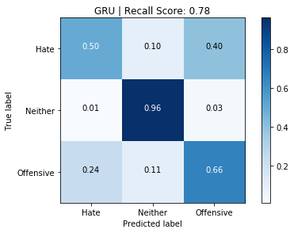

```python
summarize_rnn(gru, X_test, y_test, title_text = 'GRU')
```

The confusions from the GRU above really exemplify the difficulty in this particular classification task. Examining the confusion matrix, it is seen that the majority of the confusions are in the upper right and bottom left corners of the confusion matrix, which shows the GRU struggles the most with distinguishing between tweets containing hate speech and tweets containing offensive language. On the contrary, the GRU is easily able to detect tweets that contain neither hate speech or offensive language, with a classification accuracy of 96% in this class. The GRU above, was achieve a recall score of 78% mostly influenced by the high classification accuracy in the Neither class. However, because the real classification task of this algorithm is to distinguish hate speech from offensive language, let's look at the recall score between these two classes.

```python
yhat_gru = gru.predict_classes(X_test)
Hate_Offensive_recall = recall_score(y_test, yhat_gru, average = 'weighted', labels = [0,2])
print(f'Recall between Hate and Offensive Classes: {Hate_Offensive_recall:.2f}')
```

```
Recall between Hate and Offensive Classes: 0.61
```

Looking at these two particular classes, we can see the algorithms recall in distinguishing hate speech from offensive language is 61%.

Below, let's visualize the algorithms overall recall over the three cross validation folds to get a better sense of its generalization performance.

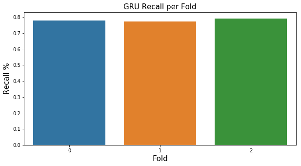

```python
gru_recll_df = pd.DataFrame(list(gru_recall.items()), columns = ['Fold', 'Recall'])
fig, ax = plt.subplots(nrows = 1, ncols = 1, figsize = (10,5))
sns.barplot(x = 'Fold', y = 'Recall', data = gru_recll_df, ax = ax)
plt.xlabel(s = 'Fold', size = 15)
plt.ylabel(s = 'Recall %', size = 15)
plt.title('GRU Recall per Fold', size = 15)
plt.show()
```

#### 7.1.1 GRU Hyperparamter Tuning

In the section below, I will explore tuning hyperparameters in the GRU to see which set of parameters yields the highest recall score. I chose to perform the hyperparameter tuning using a series of for loop because the KerasClassifier method was unnecessarily tedious. In the optimization code below, you will notice I trained the model using the X_train, and y_train_ohe datasets from above, and not over the 3-Fold cross validation method I argued as appropriate for this classification algorithm. This is because I am solely concerned with boosting performance here and examining the interplay between parameters of the GRU, not in generalization performance. That being said, once the optimal parameters are found, which yield the highest recall score, they will be placed into the GRU model and evaluated appropriately for generalization performance using the 3-Fold cross validation. Do to the amount of time it took perform the hyperparameter tuning, I chose to run the fit method for 10 epochs and assumed that the parameters to reach the highest recall score in 10 epochs were the optimal set of parameters. Again, when I place the parameters in the GRU model it will be run for a greater number of epochs.

```python
def create_gru_optimized(cells, dropout, activation, loss, optimizer):
    gru_optimized = Sequential()
    gru_optimized.add(embedding_layer)
    gru_optimized.add(GRU(cells, dropout = dropout, recurrent_dropout = dropout))
    gru_optimized.add(Dense(n_classes, activation = activation))
    gru_optimized.compile(loss = loss, optimizer = optimizer, metrics = ['accuracy'])
    return gru_optimized

# Code Reference: https://github.com/eclarson/MachineLearningNotebooks/blob/master/13.%20RNN%20Basics.ipynb
# The code above was adapted from Eric Larson's Notebook RNN Basics which can be found at the url above
```

```python
gru_optimization_dict = dict()
cells = [50, 100]
dropout = [0.1, 0.2, 0.4,]
activation = ['sigmoid', 'softmax']
loss = ['categorical_crossentropy']
optimizer = ['adam', 'rmsprop']
batch_size = [100, 500]

for c in cells:
    for d in dropout:
        for a in activation:
            for l in loss:
                for o in optimizer:
                    for b in batch_size:
                        gru_optim = create_gru_optimized(cells=c,
                                                         dropout=d,
                                                         activation=a,
                                                         loss = l,
                                                         optimizer = o)

                        gru_optim.fit(X_train, y_train_ohe, epochs = 10, verbose = 1, batch_size = b)
                        yhat = gru_optim.predict_classes(X_test)
                        recall = recall_score(y_test, yhat, average = 'weighted')
                        gru_optimization_dict[recall] = (c,d,a,l,o,b)
```

```python
pickle.dump(gru_optimization_dict, open('GRU_OPTIMIZATION/gru_optimization_dict.txt', 'wb'))
```

```python
gru_optimization_dict = pickle.load(open('GRU_OPTIMIZATION/gru_optimization_dict.txt', 'rb'))
```

```python
print('Optimal Hyperparameters (Number of Cells, Dropout, Activation, Loss, Optimization Method, Batch_size):\n',gru_optimization_dict[max(gru_optimization_dict.keys())])
```

```
Optimal Hyperparameters (Number of Cells, Dropout, Activation, Loss, Optimization Method, Batch_size):
 (100, 0.1, 'sigmoid', 'categorical_crossentropy', 'adam', 100)
```

As a result of the hyperparameter tuning for the GRU the following parameters gave the highest recall score after 10 epochs:

- Numer of Cells: 100
- Dropout: 0.1
- Activation: Sigmoid
- Loss: Categorical Crossentropy
- Optimization_Method: Adam
- Batch_size: 100

```python
def create_optimized_gru():
    optimized_gru = Sequential()
    optimized_gru.add(embedding_layer)
    optimized_gru.add(GRU(100, dropout = 0.1, recurrent_dropout = 0.1))
    optimized_gru.add(Dense(n_classes, activation = 'sigmoid'))
    optimized_gru.compile(loss = 'categorical_crossentropy', optimizer = 'adam', metrics = ['accuracy'])
    return optimized_gru

# Code Reference: https://github.com/eclarson/MachineLearningNotebooks/blob/master/13.%20RNN%20Basics.ipynb
# The code above was adapted from Eric Larson's Notebook RNN Basics which can be found at the url above
```

```python
K = 3

skf = StratifiedKFold(n_splits = K, shuffle = True, random_state = 1).split(X_train, y_train)

recall_optimized_gru = dict()

for fold, (train, test) in enumerate(skf):
    print('Fold:', fold)

    optimized_gru = create_optimized_gru()

    history_optimized_gru = optimized_gru.fit(X_train[train], to_categorical(y_train[train], n_classes),
            batch_size = 100, epochs = 25, shuffle = True, verbose = 1,
            validation_data = (X_train[test], to_categorical(y_train[test])))

    yhat = optimized_gru.predict_classes(X_train[test])
    recall = recall_score(y_train[test], yhat, average = 'weighted')

    recall_optimized_gru[fold] = recall
```

```python
optimized_gru.save('Optimized_GRU/optimized_gru.h5')
pickle.dump(history_optimized_gru.history, open('Optimized_GRU/optimized_gru_history.txt', 'wb'))
pickle.dump(recall_optimized_gru, open('Optimized_GRU/optimized_gru_recall.txt', 'wb'))
```

```python
optimized_gru = load_model('Optimized_GRU/optimized_gru.h5')
optimized_gru_history = pickle.load(open('Optimized_GRU/optimized_gru_history.txt', 'rb'))
optimized_gru_recall = pickle.load(open('Optimized_GRU/optimized_gru_recall.txt', 'rb'))
```

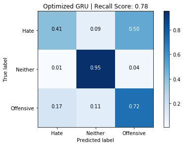

```python
summarize_rnn(optimized_gru, X_test, y_test, title_text = 'Optimized GRU')
```

In the confusions above, it is seen that with the hypertuned parameters the algorithm really just classified more tweets as offensive. This can be seen by the 6% increase in the classification accuracy in the offensive class and the 9% decrease in classification accuracy in the hate class. However, this is probably made most apparent by the 50% confusion between the two classes. These are not really promising results coming from a hypertuned model. Again, let's look at the recall score between the hate and offensive classes to examine how the algorithm performed solely upon these two classes.

```python
yhat_optimized_gru = optimized_gru.predict_classes(X_test)
Hate_Offensive_recall = recall_score(y_test, yhat_optimized_gru, average = 'weighted', labels = [0,2])
print(f'Recall between Hate and Offensive Classes: {Hate_Offensive_recall:.2f}')
```

```
Recall between Hate and Offensive Classes: 0.62
```

Let's again get a examine of the generalization performance of the algorithm by viewing the overall recall over the 3 cross validation loops.

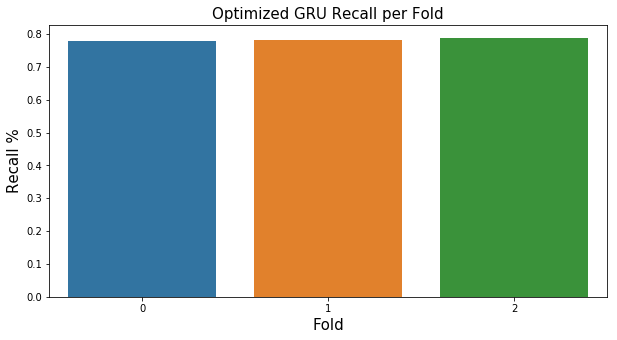

```python
optimized_gru_recll_df = pd.DataFrame(list(optimized_gru_recall.items()), columns = ['Fold', 'Recall'])
fig, ax = plt.subplots(nrows = 1, ncols = 1, figsize = (10,5))
sns.barplot(x = 'Fold', y = 'Recall', data = optimized_gru_recll_df, ax = ax)
plt.xlabel(s = 'Fold', size = 15)
plt.ylabel(s = 'Recall %', size = 15)
plt.title('Optimized GRU Recall per Fold', size = 15)
plt.show()
```

One parameter that troubled me in the results of the hyperparameter tuning was the dropout value at 0.1. This is such a small amount of dropout and from class I know using dropout in RNNs is essentially a must for generalization performance. To see if the model was over-fitting the training data due to the small amount of dropout, lets examine the training and validation accuracy over the training iterations.

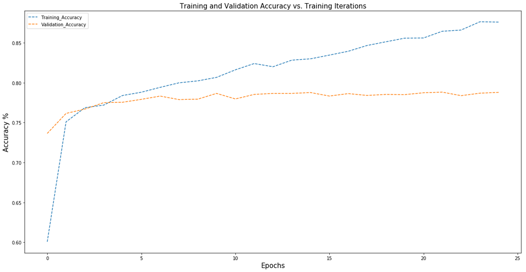

```python
%matplotlib inline
plt.figure(figsize = (20,10))
plt.plot(optimized_gru_history['acc'], label = 'Training_Accuracy', linestyle = '--')
plt.plot(optimized_gru_history['val_acc'], label = 'Validation_Accuracy', linestyle = '--')
plt.ylabel('Accuracy %', size = 15)
plt.xlabel('Epochs', size = 15)
plt.title('Training and Validation Accuracy vs. Training Iterations', size = 15)
plt.legend()
plt.show()
```

Here we can see a flaw in my methodology for tuning the hyperparameters. In examining the training and validation accuracy over the training iterations, we can see that the model is over-fitting the training data. This is most likely attributed to the small amount of dropout in the GRU. When I was performing the hyperparameter tuning, I chose to select the parameters that gave the highest recall score after 10 epochs, which resulted in a dropout of 0.1 or 10%. However, as can be seen above, by letting the network actually train for a reasonable number of epochs, using such low dropout in the network causes the model to over-fit the training data and therefore generalize poorly to the validation set.

Below, let's tune the dropout parameter a little more and see if we can fix this issue.

#### 7.1.2 Tuning Dropout

```python
def create_dropout_optimized_gru():
    dropout_optimized_gru = Sequential()
    dropout_optimized_gru.add(embedding_layer)
    dropout_optimized_gru.add(GRU(100, dropout = 0.4, recurrent_dropout = 0.4))
    dropout_optimized_gru.add(Dense(n_classes, activation = 'sigmoid'))
    dropout_optimized_gru.compile(loss = 'categorical_crossentropy', optimizer = 'adam', metrics = ['accuracy'])
    return dropout_optimized_gru

# Code Reference: https://github.com/eclarson/MachineLearningNotebooks/blob/master/13.%20RNN%20Basics.ipynb
# The code above was adapted from Eric Larson's Notebook RNN Basics which can be found at the url above
```

```python
K = 3

skf = StratifiedKFold(n_splits = K, shuffle = True, random_state = 1).split(X_train, y_train)

recall_dropout_optimized_gru = dict()

for fold, (train, test) in enumerate(skf):
    print('Fold:', fold)

    dropout_optimized_gru = create_dropout_optimized_gru()

    history_dropout_optimized_gru = dropout_optimized_gru.fit(X_train[train], to_categorical(y_train[train], n_classes),
            batch_size = 100, epochs = 50, shuffle = True, verbose = 1,
            validation_data = (X_train[test], to_categorical(y_train[test])))

    yhat = dropout_optimized_gru.predict_classes(X_train[test])
    recall = recall_score(y_train[test], yhat, average = 'weighted')

    recall_dropout_optimized_gru[fold] = recall
```

```python
dropout_optimized_gru.save('Dropout_Optimized_GRU/dropout_optimized_gru.h5')
pickle.dump(history_dropout_optimized_gru.history, open('Dropout_Optimized_GRU/dropout_optimized_gru_history.txt', 'wb'))
pickle.dump(recall_dropout_optimized_gru, open('Dropout_Optimized_GRU/dropout_optimized_gru_recall.txt', 'wb'))
```

```python
dropout_optimized_gru = load_model('Dropout_Optimized_GRU/dropout_optimized_gru.h5')
history_dropout_optimized_gru = pickle.load(open('Dropout_Optimized_GRU/dropout_optimized_gru_history.txt', 'rb'))
dropout_optimized_gru_recall = pickle.load(open('Dropout_Optimized_GRU/dropout_optimized_gru_recall.txt', 'rb'))
```

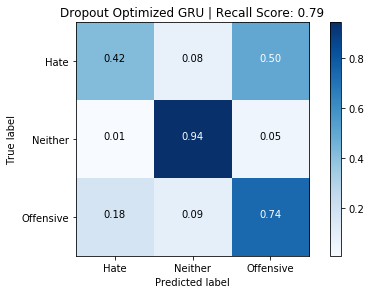

```python
summarize_rnn(dropout_optimized_gru, X_test, y_test, title_text = 'Dropout Optimized GRU')
```

With the larger amount of dropout at 40%, we do not really see any significant improvement in the confusions of this classifier. The recall score of this dropout optimized method increased by a percent, however we are still not anywhere close to our benchmark of 90%. Again, let's look at the recall between the classes we care about, hate and offensive to see if we have improved here.

```python
yhat_dropout_optimized_gru = dropout_optimized_gru.predict_classes(X_test)
Hate_Offensive_recall = recall_score(y_test, yhat_dropout_optimized_gru, average = 'weighted', labels = [0,2])
print(f'Recall between Hate and Offensive Classes: {Hate_Offensive_recall:.2f}')
```

```
Recall between Hate and Offensive Classes: 0.63
```

Once again, the recall has marginally improved by another percent to 63%. Dropout seems to have helped but ever so slightly. Let's move on and examining the training and validation accuracy over the training iterations and see if dropout has helped solve our over-fitting issue.

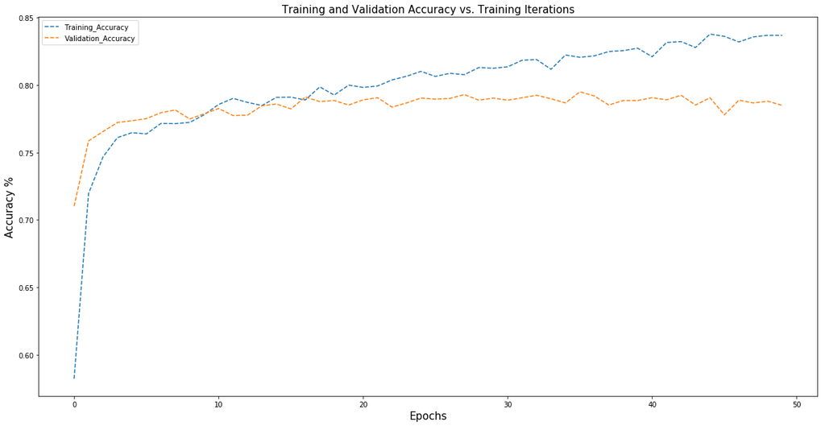

```python
%matplotlib inline
plt.figure(figsize = (20,10))
plt.plot(history_dropout_optimized_gru['acc'], label = 'Training_Accuracy', linestyle = '--')
plt.plot(history_dropout_optimized_gru['val_acc'], label = 'Validation_Accuracy', linestyle = '--')
plt.ylabel('Accuracy %', size = 15)
plt.xlabel('Epochs', size = 15)
plt.title('Training and Validation Accuracy vs. Training Iterations', size = 15)
plt.legend()
plt.show()
```

The affect of dropout here has certainly helped the model not over-fit the training data. However, over-fitting can still be seen by the continually increasing training accuracy and the flattish behavior of the validation data. Interestingly, the fact the the model over-fit the training data less, did not improve generalization accuracy very much. Maybe I have found a maximum around 79% recall.

Let's explore an LSTM and see if we can do any better with this architecture.

### 7.2 Long Short Term Memory (LSTM)

The next RNN architecture I will explore is a Long Short Term Memory (LSTM). LSTM units are composed of a cell, input gate, output gate, and a forget gate. The purpose of the LSTM cell is to memorize values over arbitrary time intervals, it deems pertinent to the classification task. Each gate in the LSTM cell acts like a neuron in a typical multi-layer perceptron, each regulating inputs and outputs. LSTMs also aim to solve the vanishing gradient problem of standard RNNs.

Again I will start with a simple RNN to get a baseline performance and then tune hyperparameters accordingly.

```python
def create_lstm():
    lstm = Sequential()
    lstm.add(embedding_layer)
    lstm.add(LSTM(100, dropout = 0.2, recurrent_dropout = 0.2))
    lstm.add(Dense(n_classes, activation = 'sigmoid'))
    lstm.compile(loss = 'categorical_crossentropy', optimizer = 'adam', metrics = ['accuracy'])
    return lstm

# Code Reference: https://github.com/eclarson/MachineLearningNotebooks/blob/master/13.%20RNN%20Basics.ipynb
# The code above was adapted from Eric Larson's Notebook RNN Basics which can be found at the url above
```

```python
K = 3

skf = StratifiedKFold(n_splits = K, shuffle = True, random_state = 1).split(X_train, y_train)

recall_lstm = dict()

for fold, (train, test) in enumerate(skf):
    print('Fold:', fold)

    lstm = create_lstm()

    lstm.fit(X_train[train], to_categorical(y_train[train], n_classes),
            batch_size = 100, epochs = 25, shuffle = True, verbose = 1,
            validation_data = (X_train[test], to_categorical(y_train[test])))

    yhat = lstm.predict_classes(X_train[test])
    recall = recall_score(y_train[test], yhat, average = 'weighted')

    recall_lstm[fold] = recall
```

```python
lstm.save('LSTM/lstm.h5')
pickle.dump(recall_lstm, open('LSTM/recall_lstm.txt', 'wb'))
```

```python
lstm = load_model('LSTM/lstm.h5')
lstm_recall = pickle.load(open('LSTM/recall_lstm.txt', 'rb'))
```

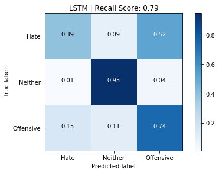

```python
summarize_rnn(lstm, X_test, y_test, title_text = 'LSTM')
```

From the confusions of the basic LSTM above, we see a similar type issue with the dropout optimized GRU, that is the algorithm is overly classifying hate tweets as offensive. This is apparent in the 52% confusion between the two classes. Basically, this simple LSTM is performing on par with the dropout optimized GRU above, which is promising in a sense. Let's again view the recall between the hate and offensive classes and see how this algorithm performs on the two.

```python
yhat_lstm = lstm.predict_classes(X_test)
Hate_Offensive_recall = recall_score(y_test, yhat_lstm, average = 'weighted', labels = [0,2])
print(f'Recall between Hate and Offensive Classes: {Hate_Offensive_recall:.2f}')
```

```
Recall between Hate and Offensive Classes: 0.62
```

The lstm again has basically performed the same as the GRUs above in classifying hate tweets from offensive tweets. Unfortunately, we are no closer to our deployable goal of 90% at 62%.

Still, let's look at how the lstm performed over the cross validation folds to get an idea of its generalization performance.

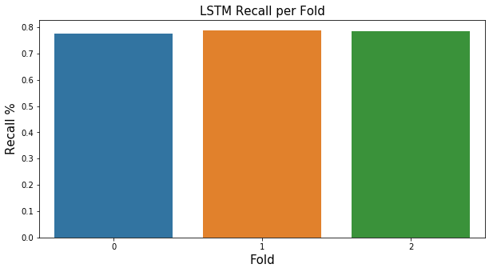

```python
lstm_recall_df = pd.DataFrame(list(lstm_recall.items()), columns = ['Fold', 'Recall'])
fig, ax = plt.subplots(nrows = 1, ncols = 1, figsize = (10,5))
sns.barplot(x = 'Fold', y = 'Recall', data = lstm_recall_df, ax = ax)
plt.xlabel(s = 'Fold', size = 15)
plt.ylabel(s = 'Recall %', size = 15)
plt.title('LSTM Recall per Fold', size = 15)
plt.show()
```

#### 7.2.1 LSTM Hyperparameter Tuning

Below, I will use the same methodology of hyperparameter tuning as I performed on the GRU above to see if I can boost the performance in terms of recall for the LSTM above.

```python
def create_lstm_optimized(cells, dropout, activation, loss, optimizer):
    lstm_optimized = Sequential()
    lstm_optimized.add(embedding_layer)
    lstm_optimized.add(LSTM(cells, dropout = dropout, recurrent_dropout = dropout))
    lstm_optimized.add(Dense(n_classes, activation = activation))
    lstm_optimized.compile(loss = loss, optimizer = optimizer, metrics = ['accuracy'])
    return lstm_optimized

# Code Reference: https://github.com/eclarson/MachineLearningNotebooks/blob/master/13.%20RNN%20Basics.ipynb
# The code above was adapted from Eric Larson's Notebook RNN Basics which can be found at the url above
```

```python
lstm_optimization_dict = dict()

cells = [50, 100]
dropout = [0.1, 0.2, 0.4,]
activation = ['sigmoid', 'softmax']
loss = ['categorical_crossentropy']
optimizer = ['adam', 'rmsprop']
batch_size = [100, 500]

for c in cells:
    for d in dropout:
        for a in activation:
            for l in loss:
                for o in optimizer:
                    for b in batch_size:
                        lstm_optim = create_lstm_optimized(cells=c,
                                                         dropout=d,
                                                         activation=a,
                                                         loss = l,
                                                         optimizer = o)

                        lstm_optim.fit(X_train, y_train_ohe, epochs = 10, verbose = 1, batch_size = b)
                        yhat = lstm_optim.predict_classes(X_test)
                        recall = recall_score(y_test, yhat, average = 'weighted')
                        lstm_optimization_dict[recall] = (c,d,a,l,o,b)
```

```python
pickle.dump(lstm_optimization_dict, open('LSTM_Optimization/lstm_optimization_dict.txt', 'wb'))
```

```python
lstm_optimization_dict = pickle.load(open('LSTM_Optimization/lstm_optimization_dict.txt', 'rb'))
```

```python
print('Optimal Hyperparameters for LSTM \n(Number of Cells, Dropout, Activation, Loss, Optimization Method, Batch_size):\n',lstm_optimization_dict[max(lstm_optimization_dict.keys())])
```

```
Optimal Hyperparameters for LSTM
(Number of Cells, Dropout, Activation, Loss, Optimization Method, Batch_size):
 (50, 0.2, 'sigmoid', 'categorical_crossentropy', 'rmsprop', 100)
```

As a result of the hyperparameter tuning for the LSTM the following parameters gave the highest recall score after 10 epochs:

- Numer of Cells: 50
- Dropout: 0.2
- Activation: Sigmoid
- Loss: Categorical Crossentropy
- Optimization_Method: rmsprop
- Batch_size: 100

```python
def create_optimized_lstm():
    optimized_lstm = Sequential()
    optimized_lstm.add(embedding_layer)
    optimized_lstm.add(LSTM(50, dropout = 0.2, recurrent_dropout = 0.2))
    optimized_lstm.add(Dense(n_classes, activation = 'sigmoid'))
    optimized_lstm.compile(loss = 'categorical_crossentropy', optimizer = 'rmsprop', metrics = ['accuracy'])
    return optimized_lstm

# Code Reference: https://github.com/eclarson/MachineLearningNotebooks/blob/master/13.%20RNN%20Basics.ipynb
# The code above was adapted from Eric Larson's Notebook RNN Basics which can be found at the url above
```

```python
K = 3

skf = StratifiedKFold(n_splits = K, shuffle = True, random_state = 1).split(X_train, y_train)

recall_optimized_lstm = dict()

for fold, (train, test) in enumerate(skf):
    print('Fold:', fold)

    optimized_lstm = create_optimized_lstm()

    optimized_lstm.fit(X_train[train], to_categorical(y_train[train], n_classes),
            batch_size = 100, epochs = 50, shuffle = True, verbose = 1,
            validation_data = (X_train[test], to_categorical(y_train[test])))

    yhat = optimized_lstm.predict_classes(X_train[test])
    recall = recall_score(y_train[test], yhat, average = 'weighted')

    recall_optimized_lstm[fold] = recall
```

```python
optimized_lstm.save('Optimized_LSTM/optimized_lstm.h5')
pickle.dump(recall_optimized_lstm, open('Optimized_LSTM/recall_optimized_lstm.txt', 'wb'))
```

```python
optimized_lstm = load_model('Optimized_LSTM/optimized_lstm.h5')
optimized_lstm_recall = pickle.load(open('Optimized_LSTM/recall_optimized_lstm.txt', 'rb'))
```

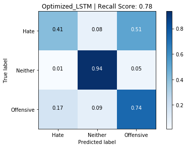

```python
summarize_rnn(optimized_lstm, X_test, y_test, title_text = 'Optimized_LSTM')
```

Unfortunately, it's the same story for the hypertuned LSTM. With the hypertuned LSTM, we see the same behavior in the classifier, a lot of hate speech being classified as offensive, and similar overall recall score.

Still, let's take a look at the recall between the hate and offensive classes and the algorithms generalization performance.

```python
yhat_optimized_lstm = optimized_lstm.predict_classes(X_test)
Hate_Offensive_recall = recall_score(y_test, yhat_optimized_lstm, average = 'weighted', labels = [0,2])
print(f'Recall between Hate and Offensive Classes: {Hate_Offensive_recall:.2f}')
```

```
Recall between Hate and Offensive Classes: 0.63
```

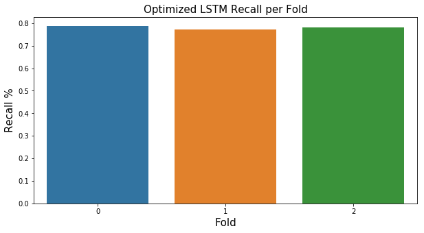

```python
optimized_lstm_recall_df = pd.DataFrame(list(optimized_lstm_recall.items()), columns = ['Fold', 'Recall'])
fig, ax = plt.subplots(nrows = 1, ncols = 1, figsize = (10,5))
sns.barplot(x = 'Fold', y = 'Recall', data = optimized_lstm_recall_df, ax = ax)
plt.xlabel(s = 'Fold', size = 15)
plt.ylabel(s = 'Recall %', size = 15)
plt.title('Optimized LSTM Recall per Fold', size = 15)
plt.show()
```

# 8. RNN Comparision

In the section below, I will compare the performance in terms of the evaluation metric (recall), of the 5 RNN architectures explored above. I begin by performing a rough comparison of the 5 models and with that, select what I believe are the two best performing models. Once the two best performing models have been determined, I will perform a T-Test and examine an ROC curve to determine the winner of the two.

### 8.1 Rough Examination

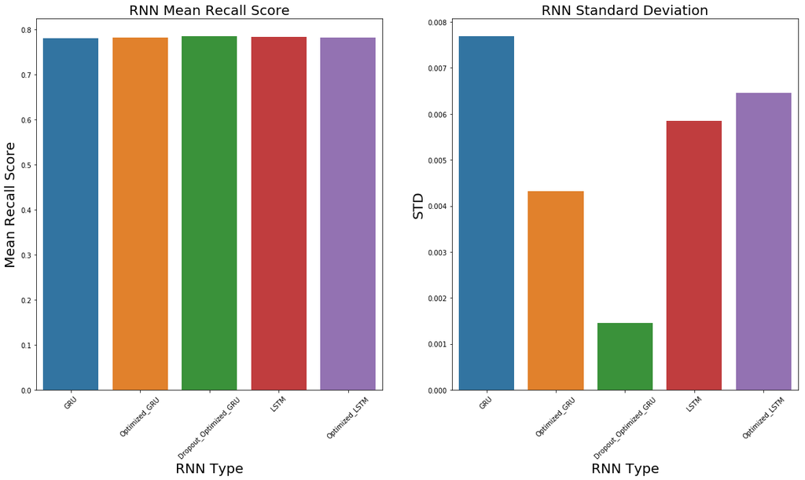

```python
gru_recall_list = []
gru_optimized_recall_list = []
gru_dropout_optimized_recall_list = []
lstm_recall_list = []
lstm_optimized_recall_list = []

[gru_recall_list.append(v) for v in gru_recall.values()]
[gru_optimized_recall_list.append(v) for v in optimized_gru_recall.values()]
[gru_dropout_optimized_recall_list.append(v) for v in dropout_optimized_gru_recall.values()]
[lstm_recall_list.append(v) for v in lstm_recall.values()]
[lstm_optimized_recall_list.append(v) for v in optimized_lstm_recall.values()]

rnn_score = [np.mean(gru_recall_list),
             np.mean(gru_optimized_recall_list),
             np.mean(gru_dropout_optimized_recall_list),
             np.mean(lstm_recall_list),
             np.mean(lstm_optimized_recall_list)]

rnn_std = [np.std(gru_recall_list),
             np.std(gru_optimized_recall_list),
             np.std(gru_dropout_optimized_recall_list),
             np.std(lstm_recall_list),
             np.std(lstm_optimized_recall_list)]

rnn_type = ['GRU', 'Optimized_GRU', 'Dropout_Optimized_GRU', 'LSTM', 'Optimized_LSTM']

rnn_compare = pd.DataFrame({'rnn_score': rnn_score,
                            'rnn_std': rnn_std,
                            'RNN_Type': rnn_type})

fig, (ax1, ax2) = plt.subplots(nrows = 1, ncols = 2, figsize = (20,10))
sns.barplot(x = 'RNN_Type', y = 'rnn_score', data = rnn_compare, ax = ax1)
sns.barplot(x = 'RNN_Type', y = 'rnn_std', data = rnn_compare, ax = ax2)
ax1.set_title('RNN Mean Recall Score', size = 20)
ax1.set_ylabel('Mean Recall Score', size = 20)
ax1.set_xlabel('RNN Type', size = 20)
ax2.set_title('RNN Standard Deviation', size = 20)
ax2.set_ylabel('STD', size = 20)
ax2.set_xlabel('RNN Type', size = 20)
ax1.set_xticklabels(rnn_type, rotation = 45)
ax2.set_xticklabels(rnn_type, rotation = 45)
plt.show()
```

To being, let's look at the mean recall score over the cross validation folds and the standard deviation in the recall scores over those same folds of the 5 models. From the plot on the left, it is seen that all RNN architectures achieved roughly the same average recall score of ~78% over the cross validation loops. Thus, the mean recall score of the RNN is not really a helpful visualization in distinguishing better models from worse models. With this, let's look at the standard deviation in the recall scores over the cross validation loops of the RNNs, and see if this visualization will be of more help in determining better models from worse models. From the plot on the right, it is seen that examining the standard deviation is incredibly helpful. From it, we can see that the Optimized_GRU and the Dropout_Optimized_GRU both achieved the lowest standard deviation in recall score over the cross validation loops of the RNN architectures explored above. As a result from this rough examination, the two best performing models are the Optimized_GRU and the Dropout_Optimized_GRU, with the Dropout_optimized_GRU said to be the better performer with the lower standard deviation.

### 8.2 T-Test

Above we established that the Dropout_Optimized_GRU was the best performing RNN with the Optimized_GRU coming in second place via the average recall score and standard deviation is recall scores over the cross validation loops for the RNN architectures. Now, let's determine if we can statistically determine which is the better RNN.

To statistically compare the performance of the RNNs, I will perform a T-Test. More specifically, I will approximate the bounds using the folds of the cross fold validation to get a mean and variance of the recall scores for the RNNs. I believe this is the most appropriate means of generating confidence intervals because both models were trained using the same data. For the T-Test, I will use a t value of 2.26 and k = 10 (note that this is lowercase k and not capital K, which indicated the number of folds in the cross validation).

If the resulting confidence interval between the two RNNs does not include 0, then statistically, with 95% confidence, I can say that the Dropout_Optimized_GRU is the better RNN.

```python
recall_score_gru_optimized = np.asarray(gru_optimized_recall_list)
recall_score_gru_dropout_optimized = np.asarray(gru_dropout_optimized_recall_list)
```

```python
k = 10
t = 2.26 / np.sqrt(k)

e = (1 - recall_score_gru_dropout_optimized) - (1 - recall_score_gru_optimized)
stdtot = np.std(e)
dbar = np.mean(e)
print('Confidence Interval:', dbar - t * stdtot, '-->', dbar + t * stdtot)
```

```
Confidence Interval: -0.005257881866407401 --> 0.0012973839408743364
```

In statistically examining the performance of the two RNNs above, I cannot say with 95% confidence which is the better RNN architecture due to the fact that the resulting confidence interval, from the T-Test, between the two includes 0.

However, let's not give up yet. Let's use another model evaluation criteria we have looked at and see if we can determine a winner.

### 8.3 ROC and AUC

Below, we are going to look at the Receiver Operating Characteristic (ROC) curve and the Area Under the Curve (AUC) as another method to compare the two best RNN architectures. ROC curves are useful tools which aid in selecting classification models based on their performance with respect to the False Positive Rate and True Positive Rate. ROC curves are constructed by shifting the decision threshold of the classifier, and counting the number of True Positives and False Positives both above and below the threshold. The diagonal of an ROC curve represents random guessing, while a perfect classifier would have a True Positive Rate of 1 and a False Positive Rate if 0, both represented in the ROC curve below. Once an ROC curve has been constructed, more information can be derived from the AUC to characterize the classification performance of a model, with a greater AUC commonly indicating a better model[4].

Below, lets compute and graphically examine the ROC and AUC of Dropout_Optimized_GRU and the Optimized_GRU and see if we can determine which is the better classifier.

[4] Raschka, Sebastian & Mirkalili, Vahid. Python Machine Learning.

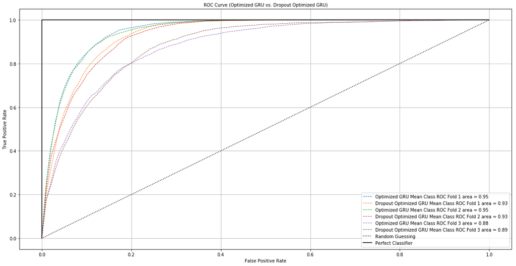

```python
% matplotlib inline
plt.figure(figsize = (20,10))

mean_tpr = 0.0
mean_fpr = np.linspace(0, 1, 100)
all_tpr = []

K = 3
skf = StratifiedKFold(n_splits = K, shuffle = True, random_state = 1).split(X_train, y_train)
for i, (train, test) in enumerate(skf):

    pred_optimized_gru = optimized_gru.predict(X_train[test])
    pred_dropout_optimized_gru = dropout_optimized_gru.predict(X_train[test])

    perclass_mean_tpr = 0.0
    roc_auc = 0
    classes = np.unique(y_test)

    for j in classes:
        fpr, tpr, thresholds = roc_curve(y_train[test],
                                         pred_optimized_gru[:,j],
                                         pos_label = j)
        perclass_mean_tpr += interp(mean_fpr, fpr, tpr)
        perclass_mean_tpr[0] = 0.0
        roc_auc += auc(fpr,tpr)

    perclass_mean_tpr /= len(classes)
    roc_auc /= len(classes)
    mean_tpr += perclass_mean_tpr

    plt.plot(mean_fpr, perclass_mean_tpr, '--', lw = 1, label = 'Optimized GRU Mean Class ROC Fold %d area = %0.2f' % (i + 1, roc_auc))

    perclass_mean_tpr = 0.0
    roc_auc = 0
    classes = np.unique(y_test)

    for j in classes:
        fpr, tpr, thresholds = roc_curve(y_train[test],
                                         pred_dropout_optimized_gru[:,j],
                                         pos_label = j)
        perclass_mean_tpr += interp(mean_fpr, fpr, tpr)
        perclass_mean_tpr[0] = 0.0
        roc_auc += auc(fpr,tpr)

    perclass_mean_tpr /= len(classes)
    roc_auc /= len(classes)
    mean_tpr += perclass_mean_tpr

    plt.plot(mean_fpr, perclass_mean_tpr, '--', lw = 1, label = 'Dropout Optimized GRU Mean Class ROC Fold %d area = %0.2f' % (i + 1, roc_auc))

# The following code is taken and slightly modified from Raschka, Sebastian & Mirkalili, Vahid. Python Machine Learning.
plt.plot([0,1], [0,1], linestyle = ':', color = 'black', label = 'Random Guessing')

plt.plot([0,0,1], [0,1,1], linestyle = '-', color = 'black', label = 'Perfect Classifier' )

plt.grid()
plt.xlabel('False Positive Rate', fontsize = 10)
plt.ylabel('True Positive Rate', fontsize = 10)
plt.title('ROC Curve (Optimized GRU vs. Dropout Optimized GRU)', fontsize = 10)
plt.legend(loc = 'best', fontsize = 10)
plt.show()
```

Using the ROC curve and AUC, lets come to a determination of which classifier is the better choice for the classification task at hand. Please note the perfect classifier and random guessing curves plotted in the graph above.

# 9. Adding a Second Recurrent Chain

Now that we have determined the best RNN architecture from the exploration above, I will add a second recurrent chain to the Optimized_GRU and visualize performance of this RNN architecture. By adding a second recurrent chain, the output sequence from the first GRU becomes the input sequence to the second GRU, thus 'chaining' RNNs together.

```python
def create_best_gru():
    best_gru = Sequential()
    best_gru.add(embedding_layer)
    best_gru.add(GRU(100, dropout = 0.1, recurrent_dropout = 0.1, return_sequences = True))
    best_gru.add(GRU(100, dropout = 0.1, recurrent_dropout = 0.1))
    best_gru.add(Dense(n_classes, activation = 'sigmoid'))
    best_gru.compile(loss = 'categorical_crossentropy', optimizer = 'adam', metrics = ['accuracy'])
    return best_gru
```

```python
K = 3

skf = StratifiedKFold(n_splits = K, shuffle = True, random_state = 1).split(X_train, y_train)

recall_train_fold0 = []
recall_train_fold1 = []
recall_train_fold2 = []

recall_test_fold0 = []
recall_test_fold1 = []
recall_test_fold2 = []

for fold, (train, test) in enumerate(skf):
    print('Fold:', fold)

    best_gru = create_best_gru()

    if fold == 0:
        epochs = 50
        for i in range(50):
            history_fold0 = best_gru.fit(X_train[train], to_categorical(y_train[train], n_classes),
                    batch_size = 100, epochs = 1, shuffle = True, verbose = 1,
                    validation_data = (X_train[test], to_categorical(y_train[test])))

            yhat_train = best_gru.predict_classes(X_train[train])
            recall_train = recall_score(y_train[train], yhat_train, average = 'weighted')
            recall_train_fold0.append(recall_train)

            yhat_test = best_gru.predict_classes(X_train[test])
            recall_test = recall_score(y_train[test], yhat_test, average = 'weighted')
            recall_test_fold0.append(recall_test)

    if fold == 1:
        epochs = 50
        for i in range(50):
            history_fold1 = best_gru.fit(X_train[train], to_categorical(y_train[train], n_classes),
                    batch_size = 100, epochs = 1, shuffle = True, verbose = 1,
                    validation_data = (X_train[test], to_categorical(y_train[test])))

            yhat_train = best_gru.predict_classes(X_train[train])
            recall_train = recall_score(y_train[train], yhat_train, average = 'weighted')
            recall_train_fold1.append(recall_train)

            yhat_test = best_gru.predict_classes(X_train[test])
            recall_test = recall_score(y_train[test], yhat_test, average = 'weighted')
            recall_test_fold1.append(recall_test)

    if fold == 2:
        epochs = 50
        for i in range(50):
            history_fold2 = best_gru.fit(X_train[train], to_categorical(y_train[train], n_classes),
                    batch_size = 100, epochs = 1, shuffle = True, verbose = 1,
                    validation_data = (X_train[test], to_categorical(y_train[test])))

            yhat_train = best_gru.predict_classes(X_train[train])
            recall_train = recall_score(y_train[train], yhat_train, average = 'weighted')
            recall_train_fold2.append(recall_train)

            yhat_test = best_gru.predict_classes(X_train[test])
            recall_test = recall_score(y_train[test], yhat_test, average = 'weighted')
            recall_test_fold2.append(recall_test)
```

```python
best_gru.save('BEST_GRU_CHAINED/best_gru.h5')
pickle.dump(recall_train_fold0, open('BEST_GRU_CHAINED/recall_train_fold0.txt', 'wb'))
pickle.dump(recall_train_fold1, open('BEST_GRU_CHAINED/recall_train_fold1.txt', 'wb'))
pickle.dump(recall_train_fold2, open('BEST_GRU_CHAINED/recall_train_fold2.txt', 'wb'))
pickle.dump(recall_test_fold0, open('BEST_GRU_CHAINED/recall_test_fold0.txt', 'wb'))
pickle.dump(recall_test_fold1, open('BEST_GRU_CHAINED/recall_test_fold1.txt', 'wb'))
pickle.dump(recall_test_fold2, open('BEST_GRU_CHAINED/recall_test_fold2.txt', 'wb'))
pickle.dump(history_fold0.history, open('BEST_GRU_CHAINED/history_fold0.txt', 'wb'))
pickle.dump(history_fold1.history, open('BEST_GRU_CHAINED/history_fold1.txt', 'wb'))
pickle.dump(history_fold2.history, open('BEST_GRU_CHAINED/history_fold2.txt', 'wb'))
```

```python
best_gru = load_model('BEST_GRU_CHAINED/best_gru.h5')
recall_train_fold0 = pickle.load(open('BEST_GRU_CHAINED/recall_train_fold0.txt', 'rb'))
recall_train_fold1 = pickle.load(open('BEST_GRU_CHAINED/recall_train_fold1.txt', 'rb'))
recall_train_fold2 = pickle.load(open('BEST_GRU_CHAINED/recall_train_fold2.txt', 'rb'))
recall_test_fold0 = pickle.load(open('BEST_GRU_CHAINED/recall_test_fold0.txt', 'rb'))
recall_test_fold1 = pickle.load(open('BEST_GRU_CHAINED/recall_test_fold1.txt', 'rb'))
recall_test_fold2 = pickle.load(open('BEST_GRU_CHAINED/recall_test_fold2.txt', 'rb'))
```

Below, let's examine the recall on the training and validation data over the training iterations.

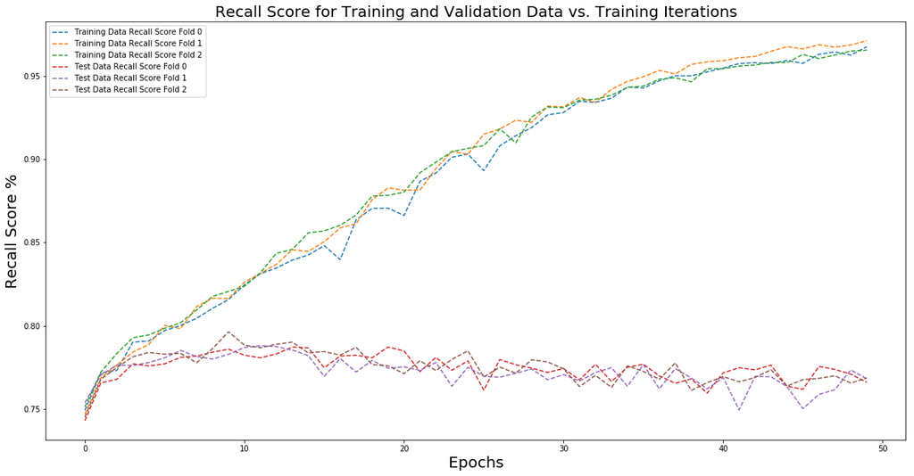

```python
%matplotlib inline
plt.figure(figsize = (20,10))

epochs = [x for x in range(50)]
plt.plot(recall_train_fold0, label = 'Training Data Recall Score Fold 0', linestyle = '--')
plt.plot(recall_train_fold1, label = 'Training Data Recall Score Fold 1', linestyle = '--')
plt.plot(recall_train_fold2, label = 'Training Data Recall Score Fold 2', linestyle = '--')
plt.plot(recall_test_fold0, label = 'Test Data Recall Score Fold 0', linestyle = '--')
plt.plot(recall_test_fold1, label = 'Test Data Recall Score Fold 1', linestyle = '--')
plt.plot(recall_test_fold2, label = 'Test Data Recall Score Fold 2', linestyle = '--')
plt.title('Recall Score for Training and Validation Data vs. Training Iterations', fontsize = 20)
plt.xlabel('Epochs', fontsize = 20)
plt.ylabel('Recall Score %', fontsize = 20)
plt.legend(loc = 'best')
plt.show()
```

In viewing the recall score on the training and validation data over the training iterations in our chained architecture, we see the model is greatly over-fitting the training data. The model actually over-fits the training data so drastically that the validation recall continuously gets worse after about 10 epochs. Let's examine the confusion matrix of this classifier and see how it performed aside from the issue of over-fitting.

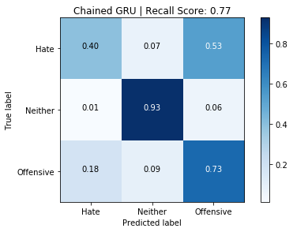

```python
summarize_rnn(best_gru, X_test, y_test, title_text = 'Chained GRU')
```

As seen by the overall recall score above, this is actually the worst performing RNN architecture (in terms of overall recall) of all the architectures explored in this lab. Even worse, the classification accuracy in the Neither class dropped by about 2%. With a more complex architecture I expected to see better classification results, however it is apparent that is not reflected here.

### 9.1 Fix Overfitting

```python
def create_best_gru_with_dropout():
    best_gru_with_dropout = Sequential()
    best_gru_with_dropout.add(embedding_layer)
    best_gru_with_dropout.add(GRU(100, dropout = 0.3, recurrent_dropout = 0.4, return_sequences = True))
    best_gru_with_dropout.add(LSTM(100, dropout = 0.4, recurrent_dropout = 0.5))
    best_gru_with_dropout.add(Dense(n_classes, activation = 'sigmoid'))
    best_gru_with_dropout.compile(loss = 'categorical_crossentropy', optimizer = 'adam', metrics = ['accuracy'])
    return best_gru_with_dropout
```

```python
K = 2

skf = StratifiedKFold(n_splits = K, shuffle = True, random_state = 1).split(X_train, y_train)

drop_recall_train_fold0 = []
drop_recall_train_fold1 = []


drop_recall_test_fold0 = []
drop_recall_test_fold1 = []


for fold, (train, test) in enumerate(skf):
    print('Fold:', fold)

    best_gru_with_dropout = create_best_gru_with_dropout()

    if fold == 0:
        epochs = 50
        for i in range(50):
            history_fold0 = best_gru_with_dropout.fit(X_train[train], to_categorical(y_train[train], n_classes),
                    batch_size = 100, epochs = 1, shuffle = True, verbose = 1,
                    validation_data = (X_train[test], to_categorical(y_train[test])))

            yhat_train = best_gru_with_dropout.predict_classes(X_train[train])
            recall_train = recall_score(y_train[train], yhat_train, average = 'weighted')
            drop_recall_train_fold0.append(recall_train)

            yhat_test = best_gru_with_dropout.predict_classes(X_train[test])
            recall_test = recall_score(y_train[test], yhat_test, average = 'weighted')
            drop_recall_test_fold0.append(recall_test)

    if fold == 1:
        epochs = 50
        for i in range(50):
            history_fold1 = best_gru_with_dropout.fit(X_train[train], to_categorical(y_train[train], n_classes),
                    batch_size = 100, epochs = 1, shuffle = True, verbose = 1,
                    validation_data = (X_train[test], to_categorical(y_train[test])))

            yhat_train = best_gru_with_dropout.predict_classes(X_train[train])
            recall_train = recall_score(y_train[train], yhat_train, average = 'weighted')
            drop_recall_train_fold1.append(recall_train)

            yhat_test = best_gru_with_dropout.predict_classes(X_train[test])
            recall_test = recall_score(y_train[test], yhat_test, average = 'weighted')
            drop_recall_test_fold1.append(recall_test)
```

```python
best_gru_with_dropout.save('CHAINED_DROPOUT/chained_with_dropout_gru.h5')
pickle.dump(drop_recall_train_fold0, open('CHAINED_DROPOUT/drop_recall_train_fold0.txt', 'wb'))
pickle.dump(drop_recall_train_fold1, open('CHAINED_DROPOUT/drop_recall_train_fold1.txt', 'wb'))
pickle.dump(drop_recall_test_fold0, open('CHAINED_DROPOUT/drop_recall_test_fold0.txt', 'wb'))
pickle.dump(drop_recall_test_fold1, open('CHAINED_DROPOUT/drop_recall_test_fold1.txt', 'wb'))
```

```python
best_gru_with_dropout = load_model('CHAINED_DROPOUT/chained_with_dropout_gru.h5')
drop_recall_train_fold0 = pickle.load(open('CHAINED_DROPOUT/drop_recall_train_fold0.txt', 'rb'))
drop_recall_train_fold1 = pickle.load(open('CHAINED_DROPOUT/drop_recall_train_fold1.txt', 'rb'))
drop_recall_test_fold0 = pickle.load(open('CHAINED_DROPOUT/drop_recall_test_fold0.txt', 'rb'))
drop_recall_test_fold1 = pickle.load(open('CHAINED_DROPOUT/drop_recall_test_fold0.txt', 'rb'))
```

Below, let's again examine the recall on the training and validation data over the training iterations for the chained RNN with the added dropout.

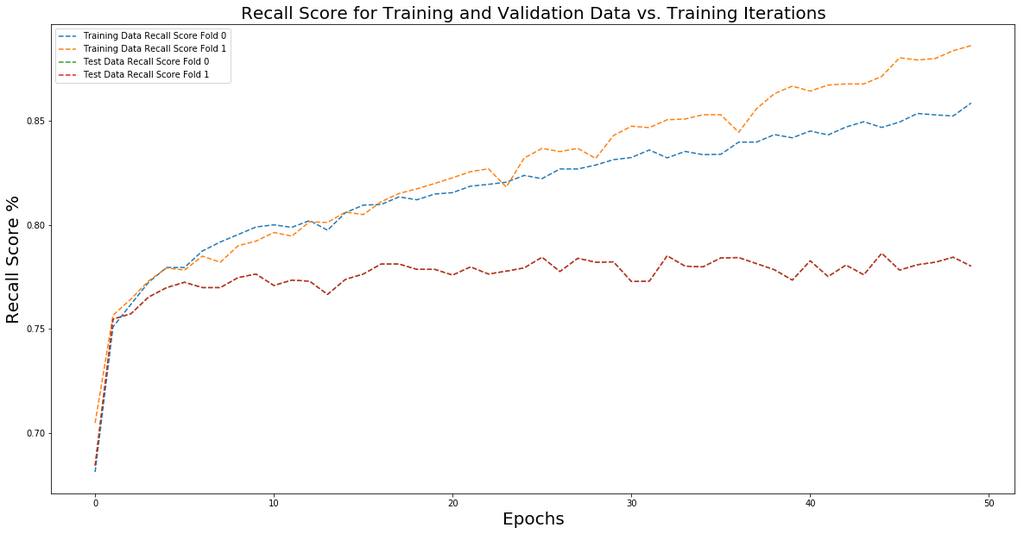

```python
%matplotlib inline
plt.figure(figsize = (20,10))

epochs = [x for x in range(50)]
plt.plot(drop_recall_train_fold0, label = 'Training Data Recall Score Fold 0', linestyle = '--')
plt.plot(drop_recall_train_fold1, label = 'Training Data Recall Score Fold 1', linestyle = '--')
plt.plot(drop_recall_test_fold0, label = 'Test Data Recall Score Fold 0', linestyle = '--')
plt.plot(drop_recall_test_fold1, label = 'Test Data Recall Score Fold 1', linestyle = '--')
plt.title('Recall Score for Training and Validation Data vs. Training Iterations', fontsize = 20)
plt.xlabel('Epochs', fontsize = 20)
plt.ylabel('Recall Score %', fontsize = 20)
plt.legend(loc = 'best')
plt.show()
```

In viewing the recall score on the training and validation data over the training iterations, the dropout helped the model not over-fit the training data somewhat, however did not completely alleviate the issue completely. Not matter what modifications I have tried to make to the RNNs in this assignment it seems I have reached a local validation accuracy around ~78%. Let's examine the confusions from this RNN and see if we gained any more performance in classification.

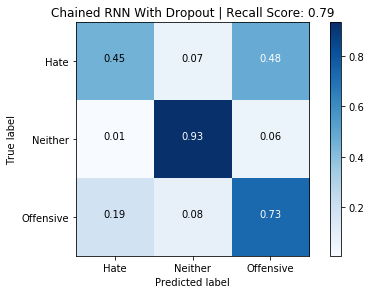

```python
summarize_rnn(best_gru_with_dropout, X_test, y_test, title_text = 'Chained RNN With Dropout')
```

Pretty much the same story here as above. Along with the majority of RNNs in this lab this particular chained architecture with the added dropout tends to over classify hate tweets as offensive as we have seen a few times above. Thus, there is not much added benefit in using more complex chained architectures with lots of dropout. Before, we completely write this off, let's look at the recall score between the hate and offensive classes for this RNN.

```python
yhat_chained_with_drop = best_gru_with_dropout.predict_classes(X_test)
Hate_Offensive_recall = recall_score(y_test, yhat_chained_with_drop, average = 'weighted', labels = [0,2])
print(f'Recall between Hate and Offensive Classes: {Hate_Offensive_recall:.2f}')
```

```
Recall between Hate and Offensive Classes: 0.64
```

Using this chained architecture we added another percent to our recall score between the hate and offensive classes, which as seen throughout this lab have been the most difficult to distinguish between.

# 10. RNN Comparison

Below, I will compare the classification performance of my best RNN versus the chained RNN with added dropout developed above. In this comparison I will cut right to the chase and jump directly to looking at the ROC curve for the two RNNs, as I believe this is the best determinant of model performance.

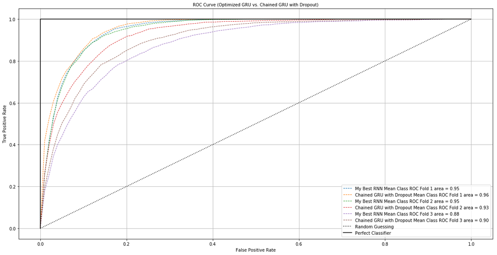

```python
% matplotlib inline
plt.figure(figsize = (20,10))

mean_tpr = 0.0
mean_fpr = np.linspace(0, 1, 100)
all_tpr = []

K = 3
skf = StratifiedKFold(n_splits = K, shuffle = True, random_state = 1).split(X_train, y_train)
for i, (train, test) in enumerate(skf):

    pred_optimized_gru = optimized_gru.predict(X_train[test])
    pred_chained_with_drop_gru = best_gru_with_dropout.predict(X_train[test])

    perclass_mean_tpr = 0.0
    roc_auc = 0
    classes = np.unique(y_test)

    for j in classes:
        fpr, tpr, thresholds = roc_curve(y_train[test],
                                         pred_optimized_gru[:,j],
                                         pos_label = j)
        perclass_mean_tpr += interp(mean_fpr, fpr, tpr)
        perclass_mean_tpr[0] = 0.0
        roc_auc += auc(fpr,tpr)

    perclass_mean_tpr /= len(classes)
    roc_auc /= len(classes)
    mean_tpr += perclass_mean_tpr

    plt.plot(mean_fpr, perclass_mean_tpr, '--', lw = 1, label = 'My Best RNN Mean Class ROC Fold %d area = %0.2f' % (i + 1, roc_auc))

    perclass_mean_tpr = 0.0
    roc_auc = 0
    classes = np.unique(y_test)

    for j in classes:
        fpr, tpr, thresholds = roc_curve(y_train[test],
                                         pred_chained_with_drop_gru[:,j],
                                         pos_label = j)
        perclass_mean_tpr += interp(mean_fpr, fpr, tpr)
        perclass_mean_tpr[0] = 0.0
        roc_auc += auc(fpr,tpr)

    perclass_mean_tpr /= len(classes)
    roc_auc /= len(classes)
    mean_tpr += perclass_mean_tpr

    plt.plot(mean_fpr, perclass_mean_tpr, '--', lw = 1, label = 'Chained GRU with Dropout Mean Class ROC Fold %d area = %0.2f' % (i + 1, roc_auc))

# The following code is taken and slightly modified from Raschka, Sebastian & Mirkalili, Vahid. Python Machine Learning.
plt.plot([0,1], [0,1], linestyle = ':', color = 'black', label = 'Random Guessing')

plt.plot([0,0,1], [0,1,1], linestyle = '-', color = 'black', label = 'Perfect Classifier' )

plt.grid()
plt.xlabel('False Positive Rate', fontsize = 10)
plt.ylabel('True Positive Rate', fontsize = 10)
plt.title('ROC Curve (Optimized GRU vs. Chained GRU with Dropout)', fontsize = 10)
plt.legend(loc = 'best', fontsize = 10)
plt.show()
```

In viewing the ROC curve for these two classifiers there is not a clear better model at first glance. We can see that over fold 1 and 3 the chained GRU slightly outperformed my best RNN indicated by its ROC curve having a greater resemblance to a perfect classifier, but over fold 2 my best RNN outperformed the chained GRU. However, because in solely looking at the ROC curves a clear better model is not apparent, let's take a look at the average area under the curve for the RNNs over the 3 folds.

The average AUC over the 3 folds for my best RNN is 0.926, while the average AUC over the three folds for the chained GRU is 0.93. With this and the ROC curve outperformance over 2 out of 3 folds, it can be determined that the chained GRU is the better classifier of the two RNNs.

# 11. Visualization of Word Embeddings

In the section below, dimensionality reduction techniques are used in an attempt to reflect and interpret meaning from the word embeddings used in the RNNs above. That is, in the code below, I will use T-Distributed Stochastic Neighbor Embedding (t-SNE) dimensionality reduction to visualize the word embeddings of a subset of words in the vocabulary of tweets in the dataset. Using t-SNE I will reduce the dimensionality of the word vectors in the glove embeddings to a dimensionality of 2, which can be more easily visualized and understood. With these visualizations, I will interpret what aspect of language is reflected in each dimension of the t-SNE embedding.

With t-SNE there are few hyperparameters that must be addressed and made sense of in relation to the data at hand, which are perplexity, n_components, and n_iter. I chose to set the perplexity to a value of 100 because the embeddings represent a complex vector embeddings of words in the tweet vocabulary. I chose to set this to a higher value because I believe the embedding data to be more complicated than a standard table of numeric values (or something of the sorts). From the scikit learn documentation on t-SNE, perplexity is related to the number of nearest neighbors that is used in other manifold learning algorithms, thus larger datasets usually require a larger perplexity. Next, the number of components (n_components) is the number of dimensions I want to reflect in the embedded space of the t-SNE dimensionality reduction method, which is 2. Lastly, the number of iterations I set to a very high value simply because the starter code I looked at had the iterations set high.

```python
# Below is the starter code I used to begin my exploration into the visualization of word embeddings.
# It should be noted I eliminated the need for a function
# Starter Code Reference URL: https://www.kaggle.com/jeffd23/visualizing-word-vectors-with-t-sne/code

# def tsne_plot(model):
#     "Creates and TSNE model and plots it"
#     labels = []
#     tokens = []

#     for word in model.wv.vocab:
#         tokens.append(model[word])
#         labels.append(word)

#     tsne_model = TSNE(perplexity=40, n_components=2, init='pca', n_iter=2500, random_state=23)
#     new_values = tsne_model.fit_transform(tokens)

#     x = []
#     y = []
#     for value in new_values:
#         x.append(value[0])
#         y.append(value[1])

#     plt.figure(figsize=(16, 16))
#     for i in range(len(x)):
#         plt.scatter(x[i],y[i])
#         plt.annotate(labels[i],
#                      xy=(x[i], y[i]),
#                      xytext=(5, 2),
#                      textcoords='offset points',
#                      ha='right',
#                      va='bottom')
#     plt.show()
```

### 11.1 A Small Subset

I chose to begin with a very simple example to get things up and running. The classic machine learning example everyone tends to use for word embedding visualization is man, women, queen, king. Here I chose to stick with a similar convention but instead use boy, girl, woman, man. Let's see what the embedded space output looks like.

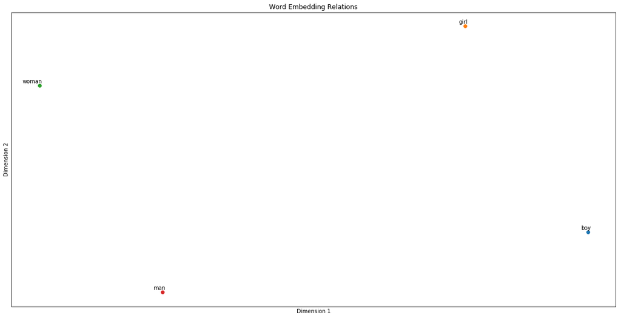

```python
word_subset = ['boy', 'girl', 'woman', 'man']
tokens = []
labels = []

for word in word_subset:
    tokens.append(embeddings_index[word])
    labels.append(word)


tsne_model = TSNE(perplexity = 100, n_components = 2, n_iter = 2500, random_state = 1)
new_values = tsne_model.fit_transform(tokens)

x = []
y = []

for value in new_values:
    x.append(value[0])
    y.append(value[1])

plt.figure(figsize = (20,10))
for i in range(len(x)):
    plt.scatter(x[i], y[i])
    plt.annotate(labels[i], xy = (x[i], y[i]), xytext = (5,2),
                 textcoords = 'offset points', ha = 'right', va = 'bottom')

plt.xlabel('Dimension 1')
plt.ylabel('Dimension 2')
plt.xticks([])
plt.yticks([])
plt.title('Word Embedding Relations')
plt.show()
```

For this particular subset of vocabulary, we can see a very interesting relationship in the word embeddings using t-SNE dimensionality reduction. Dimension 1 seems to capture temporal relations or age, while Dimension 2 seems to capture gender. I believe this to be accurate because in examining dimension 1 we see that both woman and man are located on the left hand side of the axis, while girl and boy are both located on the right hand side of the axis. This reflects the age of the individual because when people are young they tend to be referred to as girls or boys and when people are older they tend to be referred to as men or women. Thus Dimension 1 could accurately take on integer labels indicating age with in a descending manner, from left to right. Examining Dimension 2, we see that both woman and girl are located on the upper-most half of the axis and man and boy are located in the bottom-most half of the axis. Thus this axis somewhat captures a persons gender to a degree, and could accurately be labeled female in the upper-most half and male in the bottom-most half.

The spacial relations reflected in these dimensions almost seem consistent with one another. For instance the directionality and separation between woman and man and girl and boy seem roughly identical at a glance. Below, I am going to attempt to find the vector difference between woman and man and see if we can navigate from boy to girl via that same vector!

```python
# Create tuples of coordinates for each point
boy = (x[0], y[0])
girl = (x[1], y[1])
woman = (x[2], y[2])
man = (x[3], y[3])
```

```python
# Get the vector difference between man and woman
print(f'Vector difference between woman and man: {((abs(woman[0] - man[0]),abs(woman[1] - man[1])))}')
```

```
Vector difference between woman and man: (52.64203, 181.92725)
```

Now let's use these values to try to navigate from girl to boy and see how close we can get!

```python
print(f'Coordinates obtained by adding vector difference to girl: {((girl[0] + 52.64203), girl[1] - 181.92725)}')
print(f'Coordinates for boy: {boy}')
```

```
Coordinates obtained by adding vector difference to girl: (516.7230236523437, 129.8437155761719)
Coordinates for boy: (516.7231, 129.84358)
```

Look at that! By adding the vector difference obtained traveling from Woman to Man to Girl, we almost exactly arrive at Boy! This shows tremendous correlation between the relationship of boy and girl and woman and man.

### 10.2 Greater Subset

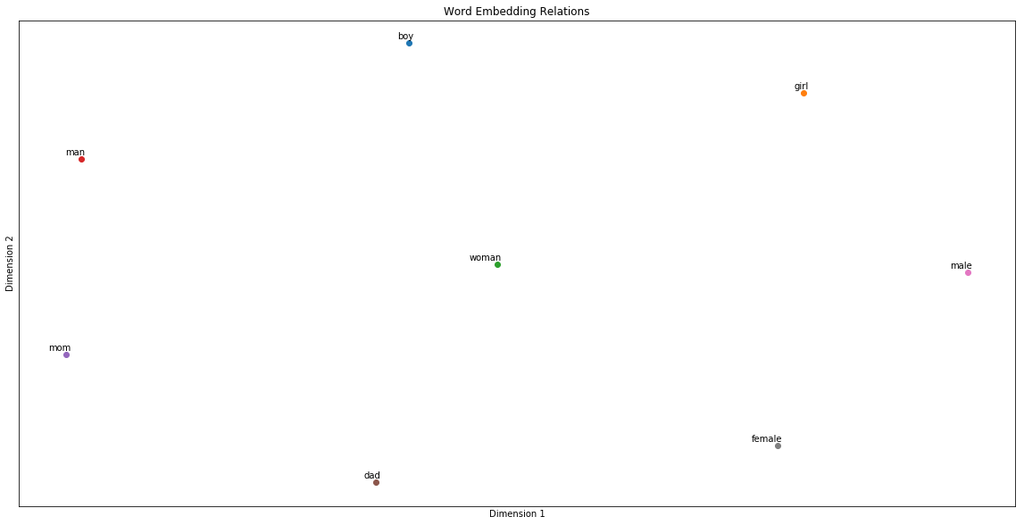

```python
word_subset = ['boy', 'girl', 'woman', 'man', 'mom', 'dad', 'male', 'female']

tokens = []
labels = []

for word in word_subset:
    tokens.append(embeddings_index[word])
    labels.append(word)


tsne_model = TSNE(perplexity = 100, n_components = 2, n_iter = 2500, random_state = 1)
new_values = tsne_model.fit_transform(tokens)

x = []
y = []

for value in new_values:
    x.append(value[0])
    y.append(value[1])

plt.figure(figsize = (20,10))
for i in range(len(x)):
    plt.scatter(x[i], y[i])
    plt.annotate(labels[i], xy = (x[i], y[i]), xytext = (5,2),
                 textcoords = 'offset points', ha = 'right', va = 'bottom')

plt.xlabel('Dimension 1')
plt.ylabel('Dimension 2')
plt.xticks([])
plt.yticks([])
plt.title('Word Embedding Relations')
plt.show()
```

In this more complex embedding space, using a greater subset of vocabulary, we do not see the same relationships above hold. However there are a few notable interesting things going on here. A directionality relationship can be see when starting at mom and moving up and to the right. In this general direction, it is seen that you will eventually intersect woman and then girl. Similarly, starting a man you see the same relationship moving up and to the right you will eventually intersect boy. However, this plot is increasingly difficult to interpret with the numerous outliers that do not meet these conventions. Of the relationships that do hold above, it could be said that Dimension 1 reflects gender relations, and Dimension 2 could possibly reflect temporal relations, which is the opposite of the first example.

Let's again choose two points that seem related and calculate a vector difference, then attempt to navigate from one point to the other using the vector. This time let's choose mom and dad and boy and girl.

```python
mom = (x[4], y[4])
dad = (x[5], y[5])
boy = (x[0], y[0])
girl = (x[1], y[1])
```

```python
# Get the vector difference between man and woman
print(f'Vector difference between woman and man: {((abs(mom[0] - dad[0]),abs(mom[1] - dad[1])))}')
```

```
Vector difference between woman and man: (88.66176, 76.099625)
```

We see the relationship is inverted for boy and girl so lets start at boy and attempt to navigate to girl this time.

```python
print(f'Coordinates obtained by adding vector difference to boy: {((boy[0] + 88.66176), boy[1] - 76.099625)}')
print(f'Coordinates for girl: {girl}')
```

```
Coordinates obtained by adding vector difference to boy: (64.897750524292, 72.64092980957031)
Coordinates for girl: (89.14024, 118.66541)
```

The relationships between mom and dad and boy and girl, with respect to vector difference do not seem to be as correlated as man and woman and girl and boy in the first example. We can see by adding the vector difference obtained from mom to dad, to boy we end up about 25 units off in Dimension 1 and 46 units off in Dimension 2.

# 11. Closing Thoughts

The primary purpose of the RNNs developed in this assignment was to classify hate speech on Twitter. The baseline comparison I wanted to beat was that achieved by Thomas Davidson, Dana Warmsley, Michael Macy, and Ingmar Weber, in their paper and exploration of this same task. Unfortunately none of the RNNs in this assignment came close to the performance needed to be considered a deployable algorithm. The highest recall score the RNNs I developed were able to obtain was around ~79%, which is 11% lower than it needed to be to beat my competition. Because of this I would not deploy this algorithm to be used by Twitter.